## ADC Peptide Mapper

v0.5 User Manual Vignette

# ADC Peptide Mapper v0.5

In-silico Tryptic Digest & Skyline Transition List Generator

Author Nishikant Wase

Correspondence nishikant.wase@gmail.com

Date April 2026

License MIT

## 1. Quick Start

The fastest path from FASTA to a Skyline-ready transition list is five steps:

1. 1

   **Install R packages** — one-time setup (see Section 2)
2. 2

   **Build background databases** — run `build_background_db.R` once (~10 min, requires internet)
3. 3

   **Launch the app** — `shiny::runApp("app.R")`
4. 4

   **Upload your ADC FASTA** → select background species → click **Run Digest & Uniqueness Check** (Tab 1)
5. 5

   **Configure instrument mode** → Generate Transition List → Download Skyline CSV (Tab 4)

## 2. Installation & Setup

### 2.1 R Package Installation

Open an R console or RStudio and run the following once:

```
install.packages(c(
  "shiny", "bs4Dash", "DT", "data.table", "openxlsx",
  "httr2", "stringr", "dplyr", "shinycssloaders", "shinyjs"
))
```

### 2.2 Build Background Databases (One-Time)

The app ships without the large proteome database files to keep the download small. Run the bundled script once to download and cache them from UniProt. An internet connection is required (~10 minutes).

```
setwd("path/to/adc_peptide_mapper")  # your unzipped folder
source("build_background_db.R")
```

This creates three files in the `data/` folder:

| File | Species | Proteins | Size |
| --- | --- | --- | --- |
| `bg_human.rds` | Human (UniProt Swiss-Prot reviewed) | ~20,442 | 23 MB |
| `bg_monkey.rds` | Cynomolgus Monkey | ~1,177 | 0.7 MB |
| `bg_rat.rds` | Rat | ~8,231 | 8.1 MB |

### 2.3 Launch the App

```
shiny::runApp("app.R")
```

**Tip:** In RStudio, open `app.R` and click the **Run App** button. The app opens in your browser at `http://127.0.0.1:XXXX`.

## 3. Application Overview

ADC Peptide Mapper is a browser-based R Shiny application with a dark navy sidebar and four sequential tabs. Work through the tabs left-to-right for a complete analysis.

| Tab | Name | Purpose |
| --- | --- | --- |
| **1** | **Input & Setup** | Upload ADC FASTA, select background proteome, configure digest parameters, run digest. |
| **2** | **Modifications** | Configure fixed, variable, special, and custom post-translational modifications. |
| **3** | **Peptide Results** | Browse, filter, and export the full modified peptide table with uniqueness flags. |
| **4** | **Transition List** | Generate and download Skyline-compatible MRM or HR transition lists. |

**Workflow summary:** The app performs in-silico trypsin digestion of your ADC sequence(s), enumerates all selected modification combinations, computes monoisotopic masses, checks each peptide's bare sequence against a pre-built background proteome digest, and flags peptides unique to your ADC. The transition list tab then calculates precursor m/z, fragment ion series (b/y/a), and empirical collision energies for direct import into Skyline.

## 4. Tab 1 — Input & Setup

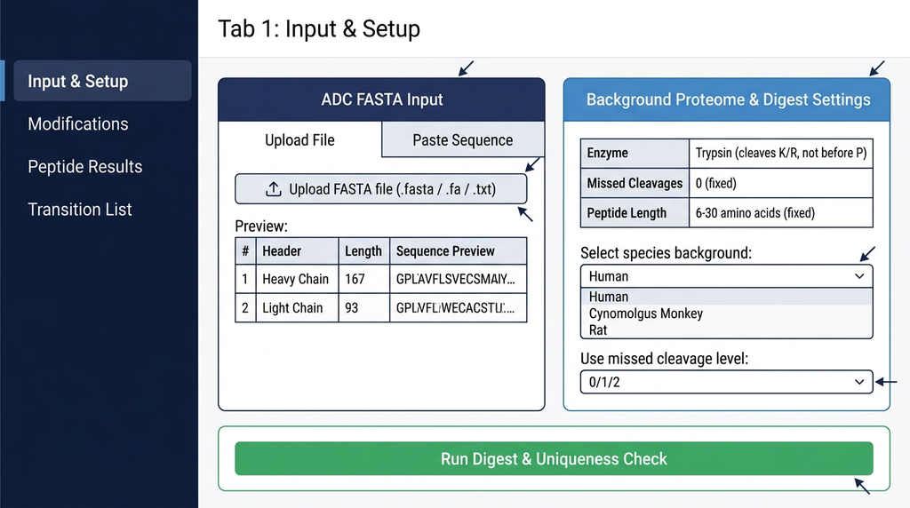

Figure 1. Tab 1: Input & Setup interface showing FASTA input, background proteome selection, and Run Digest button.

### 4.1 ADC FASTA Input

Provide your ADC sequence in FASTA format using one of two methods:

- **Upload File** — Click Browse and select a `.fasta`, `.fa`, or `.txt` file. Multi-chain FASTAs (e.g., Heavy Chain + Light Chain) are fully supported.
- **Paste Sequence** — Type or paste directly into the text area. A Trastuzumab HC+LC demo sequence is pre-loaded for immediate testing.

After input, the app automatically parses each `>header` entry as a separate chain and displays a preview table showing chain number, header name, sequence length (AA), and the first 60 residues.

### 4.2 Background Proteome Settings

| Parameter | Details |
| --- | --- |
| **Select species background** | Choose from pre-built databases: Human (~20,442 proteins), Cynomolgus Monkey (~1,177 proteins), or Rat (~8,231 proteins). Select *Custom FASTA* to upload your own background. |
| **Use missed cleavage level** | For bundled databases, all missed cleavage levels (MC=0, 1, 2) are pre-computed. Select 0 for strict uniqueness (recommended), 1 or 2 for broader background coverage. |
| **Custom FASTA upload** | Visible only when *Custom FASTA* is selected. Upload any FASTA file as background. Also select the missed cleavage level and click **Build Custom Background**. |

### 4.3 Fixed Digest Parameters

| Parameter | Value |
| --- | --- |
| Enzyme | Trypsin — cleaves after K or R, but not when followed by P (KP/RP rule) |
| Missed cleavages | 0 (fixed) |
| Peptide length | 6–30 amino acids |
| Mass type | Monoisotopic masses throughout |

### 4.4 Running the Digest

Click the **Run Digest & Uniqueness Check** button (green, bottom of page). A progress indicator appears while the app digests your ADC sequence(s), applies all selected modifications, and compares each peptide against the background. Results appear in Tab 3 when complete.

## 5. Tab 2 — Modifications

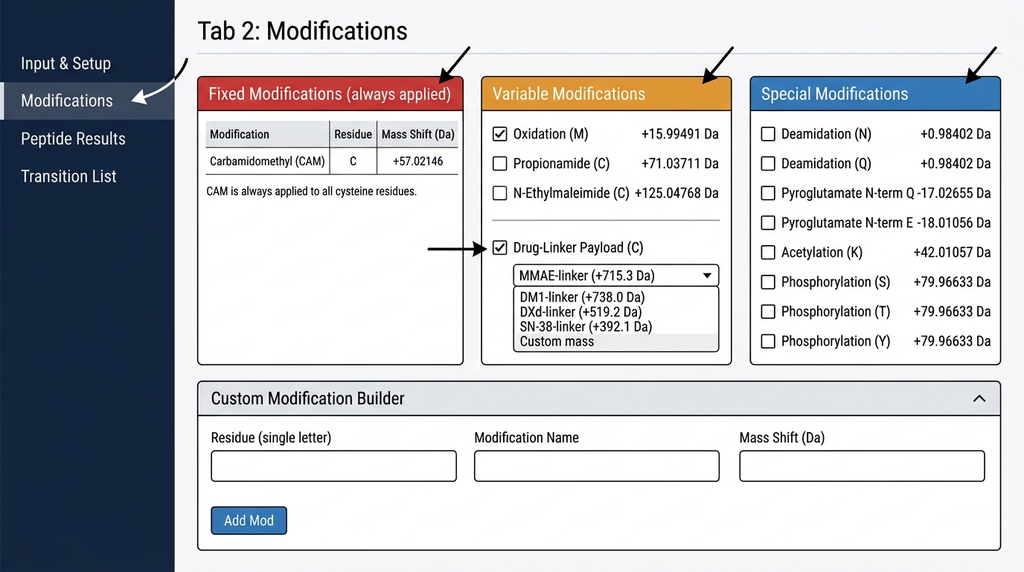

Figure 2. Tab 2: Modifications interface showing fixed, variable, special, and custom modification panels.

Configure modifications before running the digest. Changes take effect on the next **Run Digest** click.

### 5.1 Fixed Modifications (always applied)

| Modification | Residue | Mass Shift (Da) | Notation |
| --- | --- | --- | --- |
| Carbamidomethylation (CAM) | C (Cysteine) | +57.02146 | `C[CAM]` |

CAM is applied to every cysteine residue in every peptide. It cannot be disabled.

### 5.2 Variable Modifications

Each enabled variable modification generates additional peptide variants. All combinations of enabled mods are enumerated (capped at 4 variable sites per peptide to prevent combinatorial explosion).

| Modification | Residue | Mass Shift (Da) | Default | Notes |
| --- | --- | --- | --- | --- |
| Oxidation | M (Methionine) | +15.99491 | ON | Most common in-solution artifact |
| Propionamide | C (Cysteine) | +71.03711 | OFF | Acrylamide adduct from gel electrophoresis |
| N-Ethylmaleimide (NEM) | C (Cysteine) | +125.04768 | OFF | Cysteine-reactive labelling reagent |
| Drug-Linker Payload | C (Cysteine) | See below | OFF | Enable to select ADC payload |

### 5.3 Drug-Linker Payload Options

When **Drug-Linker Payload (C)** is checked, select the payload from the dropdown:

| Payload | Mass Shift (Da) | Target Residue |
| --- | --- | --- |
| MMAE-linker | +715.3 | C |
| DM1-linker | +738.0 | C |
| DXd-linker | +519.2 | C |
| SN-38-linker | +392.1 | C |
| Custom mass | User-defined numeric input | C |

### 5.4 Special Modifications

| Modification | Residue | Mass Shift (Da) | Condition |
| --- | --- | --- | --- |
| Deamidation | N (Asparagine) | +0.98402 | Any position |
| Deamidation | Q (Glutamine) | +0.98402 | Any position |
| Pyroglutamate | Q (Glutamine) | −17.02655 | N-terminal only |
| Pyroglutamate | E (Glutamic acid) | −18.01056 | N-terminal only |
| Acetylation | K (Lysine) | +42.01057 | Any position |
| Phosphorylation | S (Serine) | +79.96633 | Any position |
| Phosphorylation | T (Threonine) | +79.96633 | Any position |
| Phosphorylation | Y (Tyrosine) | +79.96633 | Any position |

### 5.5 Custom Modification Builder

Add any modification not listed above using the Custom Modification Builder panel:

- **Residue** — Single-letter amino acid code (e.g., `K`, `R`, `W`).
- **Modification Name** — A descriptive label (e.g., *Ubiquitination*).
- **Mass Shift (Da)** — Monoisotopic mass delta (positive or negative).
- Click **Add Mod** to add it to the active list. Remove entries with the delete button in the table.

## 6. Tab 3 — Peptide Results

[figure not shown]

Figure 3. Tab 3: Peptide Results showing summary value cards and the filterable peptide table with uniqueness highlighting.

### 6.1 Summary Cards

| Card | Description |
| --- | --- |
| **Total Peptides** | Total number of peptide variants generated (all chains, all mod combinations). |
| **Unique to ADC** | Peptides whose bare sequence is absent from the selected background proteome digest. |
| **Modified Peptides** | Peptide variants carrying at least one variable or special modification. |
| **Chains Detected** | Number of FASTA chains (headers) parsed from the input. |

### 6.2 Filters

| Filter | Options |
| --- | --- |
| **Filter by Chain** | Show peptides from a specific chain or All Chains. |
| **Uniqueness** | All Peptides / Unique to ADC only / Non-unique only. |
| **Modifications** | All / Modified only / Unmodified only (CAM only). |

### 6.3 Results Table Columns

| Column | Description |
| --- | --- |
| `Chain` | Chain label from the FASTA header (e.g., *Trastuzumab_HeavyChain*). |
| `Peptide Sequence` | Bare amino acid sequence (no modification annotations). |
| `Modified Sequence` | Sequence with inline modification tags, e.g. `C[CAM]`, `M[Ox]`. |
| `Start / End` | 1-based position of the peptide within the parent protein sequence. |
| `Length` | Number of amino acid residues. |
| `Modifications` | Semicolon-separated list of applied modifications with position, e.g. `Oxidation@M12`. |
| `Monoisotopic Mass` | Neutral monoisotopic mass (Da) of the modified peptide. |
| `Unique to ADC` | Yes if absent from background; No if found. |

### 6.4 Export

Click **Download Excel Summary** to export the full (filtered) peptide table as an `.xlsx` file with formatted headers. The download respects the current filter state.

## 7. Tab 4 — Transition List

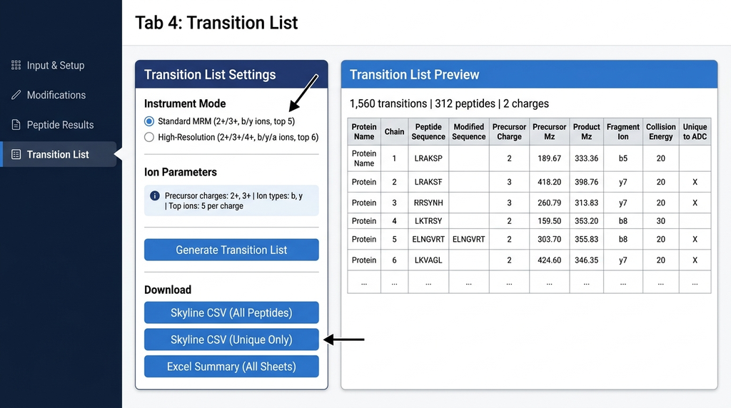

Figure 4. Tab 4: Transition List settings panel (left) and interactive preview table (right).

### 7.1 Instrument Mode

| Mode | Precursor Charges | Ion Types | Ions / Charge | Use Case |
| --- | --- | --- | --- | --- |
| **Standard MRM** | 2+, 3+ | b, y | Top 5 | Triple-quadrupole MRM (e.g., Sciex QTRAP, Waters Xevo) |
| **High-Resolution** | 2+, 3+, 4+ | b, y, a | Top 6 | High-resolution instruments (e.g., Sciex TripleTOF, Thermo Orbitrap) |

### 7.2 Ion Calculation Details

| Parameter | Formula / Details |
| --- | --- |
| Precursor m/z | `(neutral_mass + z × 1.007276) / z` |
| b-ions | `b_i = Σ residue_mass[1..i] + 1.007276` (proton) |
| y-ions | `y_i = Σ residue_mass[(n−i+1)..n] + 18.01056 + 1.007276` (water + proton) |
| a-ions (HR only) | `a_i = b_i − 27.99491` (loss of CO) |
| Product ion charge | Always z = 1 (singly charged) |
| Minimum ion size | Single-residue terminal ions (b1, y1, a1) excluded |
| Top-N selection | Ranked by fragment number (larger fragments preferred) |
| Collision Energy (CE) | `CE = 0.0448 × (m/z) − 2.0` for 2+; `0.0533 × (m/z) − 2.0` for 3+; `0.0580 × (m/z) − 2.0` for 4+. Floor: 10 eV. |

The CE formula is Sciex-style empirical. Override values in Skyline after import for other instrument vendors.

## 8. Output File Reference

### 8.1 Skyline CSV Columns

| Column | Type | Description |
| --- | --- | --- |
| `Protein Name` | Text | FASTA header of the parent protein/chain. |
| `Peptide Sequence` | Text | Bare amino acid sequence. |
| `Modified Sequence` | Text | Sequence with inline mod tags (e.g., `C[CAM]`, `M[Ox]`). |
| `Precursor Charge` | Integer | Charge state of the precursor ion (2, 3, or 4). |
| `Precursor Mz` | Decimal | Precursor m/z (5 decimal places). |
| `Product Charge` | Integer | Always 1 (singly charged fragments). |
| `Product Mz` | Decimal | Fragment ion m/z (5 decimal places). |
| `Fragment Ion` | Text | Ion label, e.g. `b5`, `y7`, `a3`. |
| `Collision Energy` | Decimal | Empirical CE in eV (1 decimal place). |
| `Unique To ADC` | Boolean | TRUE if peptide is absent from background proteome. |
| `Chain` | Text | Chain label from FASTA header. |
| `Modifications` | Text | Semicolon-separated modification list with positions. |

### 8.2 Excel Summary Workbook Sheets

| Sheet | Contents |
| --- | --- |
| **Peptide Results** | Full modified peptide table matching Tab 3 display. |
| **Transition List** | Full transition list matching Tab 4 display. |
| **Modifications** | Summary of all active modifications applied in the run. |

## 9. Scientific Background & Assumptions

### 9.1 Trypsin Digestion Rules

Trypsin cleaves peptide bonds on the C-terminal side of lysine (K) and arginine (R) residues. Cleavage is suppressed when the next residue is proline (P) — the KP and RP rules — because the cyclic structure of proline sterically hinders trypsin access. This app enforces the KP/RP rule strictly. Missed cleavages for the ADC are fixed at 0.

### 9.2 Monoisotopic Masses

All mass calculations use monoisotopic masses (most abundant isotope of each element: <sup>1</sup>H, <sup>12</sup>C, <sup>14</sup>N, <sup>16</sup>O, <sup>32</sup>S). This is the standard for high-resolution MS and MRM method development. Average masses are not used.

### 9.3 Uniqueness Definition

A peptide is flagged as **Unique to ADC** if its bare (unmodified) amino acid sequence does not appear in the background proteome digest at the selected missed cleavage level. Modifications are not considered during uniqueness comparison — only the sequence. This is intentional: a peptide unique at the sequence level remains unique regardless of which modifications are present.

### 9.4 Background Proteome Statistics

| Species | Proteins | Peptides (MC=0) | Peptides (MC=1) | Peptides (MC=2) |
| --- | --- | --- | --- | --- |
| Human (*Homo sapiens*) | 20,442 | 548,195 | 1,353,560 | 2,083,004 |
| Cynomolgus Monkey | 1,177 | 26,986 | 67,662 | 104,894 |
| Rat (*Rattus norvegicus*) | 8,231 | 210,549 | 515,946 | 788,405 |

### 9.5 Key Assumptions

| # | Assumption |
| --- | --- |
| 1 | Monoisotopic masses used throughout. |
| 2 | Trypsin KP/RP rule strictly enforced. |
| 3 | CAM on cysteine is always a fixed modification and cannot be disabled. |
| 4 | Uniqueness check uses bare (unmodified) sequences only. |
| 5 | All product ions are singly charged (z = 1). |
| 6 | Single-residue terminal ions (b1, y1, a1) are excluded from transition lists. |
| 7 | CE formula is Sciex-style empirical; override in Skyline for other vendors. |
| 8 | Variable mod combinations are capped at 4 sites per peptide to prevent combinatorial explosion. |

## 10. Troubleshooting

| Problem | Likely Cause | Solution |
| --- | --- | --- |
| App fails to start | Missing R packages | Re-run the `install.packages()` command from Section 2.1. |
| "No bundled databases found" warning | `build_background_db.R` not run, or `data/` folder missing | Run `source("build_background_db.R")` from the app directory. |
| 0 peptides generated | FASTA format error, or all peptides outside 6–30 AA filter | Check FASTA has valid `>header` lines. Verify sequence contains K/R residues. |
| All peptides show Unique = No | Wrong background species, or MC level too high | Confirm species matches your study. Try MC=0 for strictest uniqueness. |
| Transition list is empty | Peptide results empty, or Generate not clicked | Run digest first (Tab 1), then click Generate Transition List (Tab 4). |
| Skyline import fails | Column name mismatch or encoding issue | Ensure Skyline is set to import "Transition List" format. Use the unmodified CSV. |
| `build_background_db.R` fails | No internet, or UniProt API timeout | Check internet access. Re-run — it resumes from cached files. |
| Drug payload mass not applied | Drug-Linker Payload checkbox not enabled | In Tab 2, check "Drug-Linker Payload (C)", select payload, then re-run digest. |

## 11. Citation

If you use ADC Peptide Mapper in your research, please cite it using one of the formats below.

### R `citation()` format

[output not shown]

### About the DOI

**How to get a real DOI for this tool:**  
Zenodo (CERN) provides free, permanent DOIs for research software. To register one:  
1. Go to zenodo.org/deposit/new and log in (free account).  
2. Upload `ADC_Peptide_Mapper_v0.5.zip` as a new deposit.  
3. Set **Upload type** = *Software*.  
4. Fill in: Title = *ADC Peptide Mapper*, Authors = *Wase, Nishikant*, Version = *0.5*.  
5. Click **Publish** — Zenodo assigns a permanent DOI instantly (e.g., `10.5281/zenodo.NNNNNNN`).  
6. Replace `10.5281/zenodo.XXXXXXX` in this vignette and `CITATION.cff` with your real DOI.  
Each new version gets its own versioned DOI; Zenodo also provides a concept DOI that always resolves to the latest version.